# Part I: Data Overview

```python
#Importing pandas library

import pandas as pd
import matplotlib.pyplot as plt
import numpy as np
```

### 1. Reading the given csv file as a dataframe

```python
df = pd.read_csv('customers.csv', sep='\t')
df
```

|  | ID | Year_Birth | Education | Marital_Status | Income | Kidhome | Teenhome | Dt_Customer | Recency | MntWines | ... | NumWebVisitsMonth | AcceptedCmp3 | AcceptedCmp4 | AcceptedCmp5 | AcceptedCmp1 | AcceptedCmp2 | Complain | Z_CostContact | Z_Revenue | Response |
| --- | --- | --- | --- | --- | --- | --- | --- | --- | --- | --- | --- | --- | --- | --- | --- | --- | --- | --- | --- | --- | --- |
| 0 | 5524 | 1957 | Graduation | Single | 58138.0 | 0 | 0 | 04-09-2012 | 58 | 635 | ... | 7 | 0 | 0 | 0 | 0 | 0 | 0 | 3 | 11 | 1 |
| 1 | 2174 | 1954 | Graduation | Single | 46344.0 | 1 | 1 | 08-03-2014 | 38 | 11 | ... | 5 | 0 | 0 | 0 | 0 | 0 | 0 | 3 | 11 | 0 |
| 2 | 4141 | 1965 | Graduation | Together | 71613.0 | 0 | 0 | 21-08-2013 | 26 | 426 | ... | 4 | 0 | 0 | 0 | 0 | 0 | 0 | 3 | 11 | 0 |
| 3 | 6182 | 1984 | Graduation | Together | 26646.0 | 1 | 0 | 10-02-2014 | 26 | 11 | ... | 6 | 0 | 0 | 0 | 0 | 0 | 0 | 3 | 11 | 0 |
| 4 | 5324 | 1981 | PhD | Married | 58293.0 | 1 | 0 | 19-01-2014 | 94 | 173 | ... | 5 | 0 | 0 | 0 | 0 | 0 | 0 | 3 | 11 | 0 |
| ... | ... | ... | ... | ... | ... | ... | ... | ... | ... | ... | ... | ... | ... | ... | ... | ... | ... | ... | ... | ... | ... |
| 2235 | 10870 | 1967 | Graduation | Married | 61223.0 | 0 | 1 | 13-06-2013 | 46 | 709 | ... | 5 | 0 | 0 | 0 | 0 | 0 | 0 | 3 | 11 | 0 |
| 2236 | 4001 | 1946 | PhD | Together | 64014.0 | 2 | 1 | 10-06-2014 | 56 | 406 | ... | 7 | 0 | 0 | 0 | 1 | 0 | 0 | 3 | 11 | 0 |
| 2237 | 7270 | 1981 | Graduation | Divorced | 56981.0 | 0 | 0 | 25-01-2014 | 91 | 908 | ... | 6 | 0 | 1 | 0 | 0 | 0 | 0 | 3 | 11 | 0 |
| 2238 | 8235 | 1956 | Master | Together | 69245.0 | 0 | 1 | 24-01-2014 | 8 | 428 | ... | 3 | 0 | 0 | 0 | 0 | 0 | 0 | 3 | 11 | 0 |
| 2239 | 9405 | 1954 | PhD | Married | 52869.0 | 1 | 1 | 15-10-2012 | 40 | 84 | ... | 7 | 0 | 0 | 0 | 0 | 0 | 0 | 3 | 11 | 1 |

2240 rows × 29 columns

### 2.1 Displaying the first 5 rows of the dataframe

```python
df.head(5)
```

|  | ID | Year_Birth | Education | Marital_Status | Income | Kidhome | Teenhome | Dt_Customer | Recency | MntWines | ... | NumWebVisitsMonth | AcceptedCmp3 | AcceptedCmp4 | AcceptedCmp5 | AcceptedCmp1 | AcceptedCmp2 | Complain | Z_CostContact | Z_Revenue | Response |
| --- | --- | --- | --- | --- | --- | --- | --- | --- | --- | --- | --- | --- | --- | --- | --- | --- | --- | --- | --- | --- | --- |
| 0 | 5524 | 1957 | Graduation | Single | 58138.0 | 0 | 0 | 04-09-2012 | 58 | 635 | ... | 7 | 0 | 0 | 0 | 0 | 0 | 0 | 3 | 11 | 1 |
| 1 | 2174 | 1954 | Graduation | Single | 46344.0 | 1 | 1 | 08-03-2014 | 38 | 11 | ... | 5 | 0 | 0 | 0 | 0 | 0 | 0 | 3 | 11 | 0 |
| 2 | 4141 | 1965 | Graduation | Together | 71613.0 | 0 | 0 | 21-08-2013 | 26 | 426 | ... | 4 | 0 | 0 | 0 | 0 | 0 | 0 | 3 | 11 | 0 |
| 3 | 6182 | 1984 | Graduation | Together | 26646.0 | 1 | 0 | 10-02-2014 | 26 | 11 | ... | 6 | 0 | 0 | 0 | 0 | 0 | 0 | 3 | 11 | 0 |
| 4 | 5324 | 1981 | PhD | Married | 58293.0 | 1 | 0 | 19-01-2014 | 94 | 173 | ... | 5 | 0 | 0 | 0 | 0 | 0 | 0 | 3 | 11 | 0 |

5 rows × 29 columns

### 2.2 Displaying the last 3 rows of the dataframe

```python
df.tail(3)
```

|  | ID | Year_Birth | Education | Marital_Status | Income | Kidhome | Teenhome | Dt_Customer | Recency | MntWines | ... | NumWebVisitsMonth | AcceptedCmp3 | AcceptedCmp4 | AcceptedCmp5 | AcceptedCmp1 | AcceptedCmp2 | Complain | Z_CostContact | Z_Revenue | Response |
| --- | --- | --- | --- | --- | --- | --- | --- | --- | --- | --- | --- | --- | --- | --- | --- | --- | --- | --- | --- | --- | --- |
| 2237 | 7270 | 1981 | Graduation | Divorced | 56981.0 | 0 | 0 | 25-01-2014 | 91 | 908 | ... | 6 | 0 | 1 | 0 | 0 | 0 | 0 | 3 | 11 | 0 |
| 2238 | 8235 | 1956 | Master | Together | 69245.0 | 0 | 1 | 24-01-2014 | 8 | 428 | ... | 3 | 0 | 0 | 0 | 0 | 0 | 0 | 3 | 11 | 0 |
| 2239 | 9405 | 1954 | PhD | Married | 52869.0 | 1 | 1 | 15-10-2012 | 40 | 84 | ... | 7 | 0 | 0 | 0 | 0 | 0 | 0 | 3 | 11 | 1 |

3 rows × 29 columns

### 3. Displaying the quick statistics of the dataframe

```python
df.describe()
```

|  | ID | Year_Birth | Income | Kidhome | Teenhome | Recency | MntWines | MntFruits | MntMeatProducts | MntFishProducts | ... | NumWebVisitsMonth | AcceptedCmp3 | AcceptedCmp4 | AcceptedCmp5 | AcceptedCmp1 | AcceptedCmp2 | Complain | Z_CostContact | Z_Revenue | Response |
| --- | --- | --- | --- | --- | --- | --- | --- | --- | --- | --- | --- | --- | --- | --- | --- | --- | --- | --- | --- | --- | --- |
| count | 2240.000000 | 2240.000000 | 2216.000000 | 2240.000000 | 2240.000000 | 2240.000000 | 2240.000000 | 2240.000000 | 2240.000000 | 2240.000000 | ... | 2240.000000 | 2240.000000 | 2240.000000 | 2240.000000 | 2240.000000 | 2240.000000 | 2240.000000 | 2240.0 | 2240.0 | 2240.000000 |
| mean | 5592.159821 | 1968.805804 | 52247.251354 | 0.444196 | 0.506250 | 49.109375 | 303.935714 | 26.302232 | 166.950000 | 37.525446 | ... | 5.316518 | 0.072768 | 0.074554 | 0.072768 | 0.064286 | 0.013393 | 0.009375 | 3.0 | 11.0 | 0.149107 |
| std | 3246.662198 | 11.984069 | 25173.076661 | 0.538398 | 0.544538 | 28.962453 | 336.597393 | 39.773434 | 225.715373 | 54.628979 | ... | 2.426645 | 0.259813 | 0.262728 | 0.259813 | 0.245316 | 0.114976 | 0.096391 | 0.0 | 0.0 | 0.356274 |
| min | 0.000000 | 1893.000000 | 1730.000000 | 0.000000 | 0.000000 | 0.000000 | 0.000000 | 0.000000 | 0.000000 | 0.000000 | ... | 0.000000 | 0.000000 | 0.000000 | 0.000000 | 0.000000 | 0.000000 | 0.000000 | 3.0 | 11.0 | 0.000000 |
| 25% | 2828.250000 | 1959.000000 | 35303.000000 | 0.000000 | 0.000000 | 24.000000 | 23.750000 | 1.000000 | 16.000000 | 3.000000 | ... | 3.000000 | 0.000000 | 0.000000 | 0.000000 | 0.000000 | 0.000000 | 0.000000 | 3.0 | 11.0 | 0.000000 |
| 50% | 5458.500000 | 1970.000000 | 51381.500000 | 0.000000 | 0.000000 | 49.000000 | 173.500000 | 8.000000 | 67.000000 | 12.000000 | ... | 6.000000 | 0.000000 | 0.000000 | 0.000000 | 0.000000 | 0.000000 | 0.000000 | 3.0 | 11.0 | 0.000000 |
| 75% | 8427.750000 | 1977.000000 | 68522.000000 | 1.000000 | 1.000000 | 74.000000 | 504.250000 | 33.000000 | 232.000000 | 50.000000 | ... | 7.000000 | 0.000000 | 0.000000 | 0.000000 | 0.000000 | 0.000000 | 0.000000 | 3.0 | 11.0 | 0.000000 |
| max | 11191.000000 | 1996.000000 | 666666.000000 | 2.000000 | 2.000000 | 99.000000 | 1493.000000 | 199.000000 | 1725.000000 | 259.000000 | ... | 20.000000 | 1.000000 | 1.000000 | 1.000000 | 1.000000 | 1.000000 | 1.000000 | 3.0 | 11.0 | 1.000000 |

8 rows × 26 columns

### 4. Displaying the data type of each column

```python
df.dtypes
```

```
ID                       int64
Year_Birth               int64
Education               object
Marital_Status          object
Income                 float64
Kidhome                  int64
Teenhome                 int64
Dt_Customer             object
Recency                  int64
MntWines                 int64
MntFruits                int64
MntMeatProducts          int64
MntFishProducts          int64
MntSweetProducts         int64
MntGoldProds             int64
NumDealsPurchases        int64
NumWebPurchases          int64
NumCatalogPurchases      int64
NumStorePurchases        int64
NumWebVisitsMonth        int64
AcceptedCmp3             int64
AcceptedCmp4             int64
AcceptedCmp5             int64
AcceptedCmp1             int64
AcceptedCmp2             int64
Complain                 int64
Z_CostContact            int64
Z_Revenue                int64
Response                 int64
dtype: object
```

### 5. Displaying number of columns and rows of my dataframe

```python
df.shape
```

```
(2240, 29)
```

### 6. Displaying the list of columns in the dataframe

```python
df.columns
```

```
Index(['ID', 'Year_Birth', 'Education', 'Marital_Status', 'Income', 'Kidhome',
       'Teenhome', 'Dt_Customer', 'Recency', 'MntWines', 'MntFruits',
       'MntMeatProducts', 'MntFishProducts', 'MntSweetProducts',
       'MntGoldProds', 'NumDealsPurchases', 'NumWebPurchases',
       'NumCatalogPurchases', 'NumStorePurchases', 'NumWebVisitsMonth',
       'AcceptedCmp3', 'AcceptedCmp4', 'AcceptedCmp5', 'AcceptedCmp1',
       'AcceptedCmp2', 'Complain', 'Z_CostContact', 'Z_Revenue', 'Response'],
      dtype='object')
```

### 7. Displaying the number of duplicated rows in the dataframe

```python
num_duplicates_df = df.duplicated().sum()

print("Number of duplicated rows:", num_duplicates_df)
```

```
Number of duplicated rows: 0
```

# Part II: Data Preparation and Cleaning

### 8. Rename the columns belonging to Products by removing Mnt from them.

```python
df.rename(columns={'MntWines': 'Wines',
                     'MntFruits': 'Fruits',
                     'MntMeatProducts': 'Meat',
                     'MntFishProducts': 'Fish',
                     'MntSweetProducts': 'Sweet',
                     'MntGoldProds': 'Gold'}, inplace=True)

df.columns
```

```
Index(['ID', 'Year_Birth', 'Education', 'Marital_Status', 'Income', 'Kidhome',
       'Teenhome', 'Dt_Customer', 'Recency', 'Wines', 'Fruits', 'Meat', 'Fish',
       'Sweet', 'Gold', 'NumDealsPurchases', 'NumWebPurchases',
       'NumCatalogPurchases', 'NumStorePurchases', 'NumWebVisitsMonth',
       'AcceptedCmp3', 'AcceptedCmp4', 'AcceptedCmp5', 'AcceptedCmp1',
       'AcceptedCmp2', 'Complain', 'Z_CostContact', 'Z_Revenue', 'Response'],
      dtype='object')
```

### 9. Rename the columnsbelonging to Place by removing Num and Purchases from them

```python
df.rename(columns={'NumWebPurchases': 'Web',
                     'NumCatalogPurchases': 'Catalog',
                     'NumStorePurchases': 'Store'}, inplace=True)

df.columns
```

```
Index(['ID', 'Year_Birth', 'Education', 'Marital_Status', 'Income', 'Kidhome',
       'Teenhome', 'Dt_Customer', 'Recency', 'Wines', 'Fruits', 'Meat', 'Fish',
       'Sweet', 'Gold', 'NumDealsPurchases', 'Web', 'Catalog', 'Store',
       'NumWebVisitsMonth', 'AcceptedCmp3', 'AcceptedCmp4', 'AcceptedCmp5',
       'AcceptedCmp1', 'AcceptedCmp2', 'Complain', 'Z_CostContact',
       'Z_Revenue', 'Response'],
      dtype='object')
```

### 10. Keep only NumDealsPurchases column in the Promotion section

```python
columns_to_delete = ['AcceptedCmp1', 'AcceptedCmp2', 'AcceptedCmp3', 'AcceptedCmp4', 'AcceptedCmp5', 'Response']
df.drop(columns=columns_to_delete, inplace=True)
df
```

|  | ID | Year_Birth | Education | Marital_Status | Income | Kidhome | Teenhome | Dt_Customer | Recency | Wines | ... | Sweet | Gold | NumDealsPurchases | Web | Catalog | Store | NumWebVisitsMonth | Complain | Z_CostContact | Z_Revenue |
| --- | --- | --- | --- | --- | --- | --- | --- | --- | --- | --- | --- | --- | --- | --- | --- | --- | --- | --- | --- | --- | --- |
| 0 | 5524 | 1957 | Graduation | Single | 58138.0 | 0 | 0 | 04-09-2012 | 58 | 635 | ... | 88 | 88 | 3 | 8 | 10 | 4 | 7 | 0 | 3 | 11 |
| 1 | 2174 | 1954 | Graduation | Single | 46344.0 | 1 | 1 | 08-03-2014 | 38 | 11 | ... | 1 | 6 | 2 | 1 | 1 | 2 | 5 | 0 | 3 | 11 |
| 2 | 4141 | 1965 | Graduation | Together | 71613.0 | 0 | 0 | 21-08-2013 | 26 | 426 | ... | 21 | 42 | 1 | 8 | 2 | 10 | 4 | 0 | 3 | 11 |
| 3 | 6182 | 1984 | Graduation | Together | 26646.0 | 1 | 0 | 10-02-2014 | 26 | 11 | ... | 3 | 5 | 2 | 2 | 0 | 4 | 6 | 0 | 3 | 11 |
| 4 | 5324 | 1981 | PhD | Married | 58293.0 | 1 | 0 | 19-01-2014 | 94 | 173 | ... | 27 | 15 | 5 | 5 | 3 | 6 | 5 | 0 | 3 | 11 |
| ... | ... | ... | ... | ... | ... | ... | ... | ... | ... | ... | ... | ... | ... | ... | ... | ... | ... | ... | ... | ... | ... |
| 2235 | 10870 | 1967 | Graduation | Married | 61223.0 | 0 | 1 | 13-06-2013 | 46 | 709 | ... | 118 | 247 | 2 | 9 | 3 | 4 | 5 | 0 | 3 | 11 |
| 2236 | 4001 | 1946 | PhD | Together | 64014.0 | 2 | 1 | 10-06-2014 | 56 | 406 | ... | 0 | 8 | 7 | 8 | 2 | 5 | 7 | 0 | 3 | 11 |
| 2237 | 7270 | 1981 | Graduation | Divorced | 56981.0 | 0 | 0 | 25-01-2014 | 91 | 908 | ... | 12 | 24 | 1 | 2 | 3 | 13 | 6 | 0 | 3 | 11 |
| 2238 | 8235 | 1956 | Master | Together | 69245.0 | 0 | 1 | 24-01-2014 | 8 | 428 | ... | 30 | 61 | 2 | 6 | 5 | 10 | 3 | 0 | 3 | 11 |
| 2239 | 9405 | 1954 | PhD | Married | 52869.0 | 1 | 1 | 15-10-2012 | 40 | 84 | ... | 1 | 21 | 3 | 3 | 1 | 4 | 7 | 0 | 3 | 11 |

2240 rows × 23 columns

### 11. Delete the column NumWebVisitsMonth

```python
df.drop(columns='NumWebVisitsMonth', inplace=True)
df
```

|  | ID | Year_Birth | Education | Marital_Status | Income | Kidhome | Teenhome | Dt_Customer | Recency | Wines | ... | Fish | Sweet | Gold | NumDealsPurchases | Web | Catalog | Store | Complain | Z_CostContact | Z_Revenue |
| --- | --- | --- | --- | --- | --- | --- | --- | --- | --- | --- | --- | --- | --- | --- | --- | --- | --- | --- | --- | --- | --- |
| 0 | 5524 | 1957 | Graduation | Single | 58138.0 | 0 | 0 | 04-09-2012 | 58 | 635 | ... | 172 | 88 | 88 | 3 | 8 | 10 | 4 | 0 | 3 | 11 |
| 1 | 2174 | 1954 | Graduation | Single | 46344.0 | 1 | 1 | 08-03-2014 | 38 | 11 | ... | 2 | 1 | 6 | 2 | 1 | 1 | 2 | 0 | 3 | 11 |
| 2 | 4141 | 1965 | Graduation | Together | 71613.0 | 0 | 0 | 21-08-2013 | 26 | 426 | ... | 111 | 21 | 42 | 1 | 8 | 2 | 10 | 0 | 3 | 11 |
| 3 | 6182 | 1984 | Graduation | Together | 26646.0 | 1 | 0 | 10-02-2014 | 26 | 11 | ... | 10 | 3 | 5 | 2 | 2 | 0 | 4 | 0 | 3 | 11 |
| 4 | 5324 | 1981 | PhD | Married | 58293.0 | 1 | 0 | 19-01-2014 | 94 | 173 | ... | 46 | 27 | 15 | 5 | 5 | 3 | 6 | 0 | 3 | 11 |
| ... | ... | ... | ... | ... | ... | ... | ... | ... | ... | ... | ... | ... | ... | ... | ... | ... | ... | ... | ... | ... | ... |
| 2235 | 10870 | 1967 | Graduation | Married | 61223.0 | 0 | 1 | 13-06-2013 | 46 | 709 | ... | 42 | 118 | 247 | 2 | 9 | 3 | 4 | 0 | 3 | 11 |
| 2236 | 4001 | 1946 | PhD | Together | 64014.0 | 2 | 1 | 10-06-2014 | 56 | 406 | ... | 0 | 0 | 8 | 7 | 8 | 2 | 5 | 0 | 3 | 11 |
| 2237 | 7270 | 1981 | Graduation | Divorced | 56981.0 | 0 | 0 | 25-01-2014 | 91 | 908 | ... | 32 | 12 | 24 | 1 | 2 | 3 | 13 | 0 | 3 | 11 |
| 2238 | 8235 | 1956 | Master | Together | 69245.0 | 0 | 1 | 24-01-2014 | 8 | 428 | ... | 80 | 30 | 61 | 2 | 6 | 5 | 10 | 0 | 3 | 11 |
| 2239 | 9405 | 1954 | PhD | Married | 52869.0 | 1 | 1 | 15-10-2012 | 40 | 84 | ... | 2 | 1 | 21 | 3 | 3 | 1 | 4 | 0 | 3 | 11 |

2240 rows × 22 columns

### 12. The attribute Year_Birth is not helpful to segment your data. Instead create a new derived column named Age.

```python
from datetime import datetime
current_year = datetime.now().year

df['Age'] = current_year - df['Year_Birth']
df
```

|  | ID | Year_Birth | Education | Marital_Status | Income | Kidhome | Teenhome | Dt_Customer | Recency | Wines | ... | Sweet | Gold | NumDealsPurchases | Web | Catalog | Store | Complain | Z_CostContact | Z_Revenue | Age |
| --- | --- | --- | --- | --- | --- | --- | --- | --- | --- | --- | --- | --- | --- | --- | --- | --- | --- | --- | --- | --- | --- |
| 0 | 5524 | 1957 | Graduation | Single | 58138.0 | 0 | 0 | 04-09-2012 | 58 | 635 | ... | 88 | 88 | 3 | 8 | 10 | 4 | 0 | 3 | 11 | 67 |
| 1 | 2174 | 1954 | Graduation | Single | 46344.0 | 1 | 1 | 08-03-2014 | 38 | 11 | ... | 1 | 6 | 2 | 1 | 1 | 2 | 0 | 3 | 11 | 70 |
| 2 | 4141 | 1965 | Graduation | Together | 71613.0 | 0 | 0 | 21-08-2013 | 26 | 426 | ... | 21 | 42 | 1 | 8 | 2 | 10 | 0 | 3 | 11 | 59 |
| 3 | 6182 | 1984 | Graduation | Together | 26646.0 | 1 | 0 | 10-02-2014 | 26 | 11 | ... | 3 | 5 | 2 | 2 | 0 | 4 | 0 | 3 | 11 | 40 |
| 4 | 5324 | 1981 | PhD | Married | 58293.0 | 1 | 0 | 19-01-2014 | 94 | 173 | ... | 27 | 15 | 5 | 5 | 3 | 6 | 0 | 3 | 11 | 43 |
| ... | ... | ... | ... | ... | ... | ... | ... | ... | ... | ... | ... | ... | ... | ... | ... | ... | ... | ... | ... | ... | ... |
| 2235 | 10870 | 1967 | Graduation | Married | 61223.0 | 0 | 1 | 13-06-2013 | 46 | 709 | ... | 118 | 247 | 2 | 9 | 3 | 4 | 0 | 3 | 11 | 57 |
| 2236 | 4001 | 1946 | PhD | Together | 64014.0 | 2 | 1 | 10-06-2014 | 56 | 406 | ... | 0 | 8 | 7 | 8 | 2 | 5 | 0 | 3 | 11 | 78 |
| 2237 | 7270 | 1981 | Graduation | Divorced | 56981.0 | 0 | 0 | 25-01-2014 | 91 | 908 | ... | 12 | 24 | 1 | 2 | 3 | 13 | 0 | 3 | 11 | 43 |
| 2238 | 8235 | 1956 | Master | Together | 69245.0 | 0 | 1 | 24-01-2014 | 8 | 428 | ... | 30 | 61 | 2 | 6 | 5 | 10 | 0 | 3 | 11 | 68 |
| 2239 | 9405 | 1954 | PhD | Married | 52869.0 | 1 | 1 | 15-10-2012 | 40 | 84 | ... | 1 | 21 | 3 | 3 | 1 | 4 | 0 | 3 | 11 | 70 |

2240 rows × 23 columns

### 13. Create a new column named Spending that holds the total amount spent on all products categories.

```python
df['Spending'] = df[['Wines', 'Fruits', 'Meat', 'Fish', 'Sweet', 'Gold']].sum(axis=1)
df
```

|  | ID | Year_Birth | Education | Marital_Status | Income | Kidhome | Teenhome | Dt_Customer | Recency | Wines | ... | Gold | NumDealsPurchases | Web | Catalog | Store | Complain | Z_CostContact | Z_Revenue | Age | Spending |
| --- | --- | --- | --- | --- | --- | --- | --- | --- | --- | --- | --- | --- | --- | --- | --- | --- | --- | --- | --- | --- | --- |
| 0 | 5524 | 1957 | Graduation | Single | 58138.0 | 0 | 0 | 04-09-2012 | 58 | 635 | ... | 88 | 3 | 8 | 10 | 4 | 0 | 3 | 11 | 67 | 1617 |
| 1 | 2174 | 1954 | Graduation | Single | 46344.0 | 1 | 1 | 08-03-2014 | 38 | 11 | ... | 6 | 2 | 1 | 1 | 2 | 0 | 3 | 11 | 70 | 27 |
| 2 | 4141 | 1965 | Graduation | Together | 71613.0 | 0 | 0 | 21-08-2013 | 26 | 426 | ... | 42 | 1 | 8 | 2 | 10 | 0 | 3 | 11 | 59 | 776 |
| 3 | 6182 | 1984 | Graduation | Together | 26646.0 | 1 | 0 | 10-02-2014 | 26 | 11 | ... | 5 | 2 | 2 | 0 | 4 | 0 | 3 | 11 | 40 | 53 |
| 4 | 5324 | 1981 | PhD | Married | 58293.0 | 1 | 0 | 19-01-2014 | 94 | 173 | ... | 15 | 5 | 5 | 3 | 6 | 0 | 3 | 11 | 43 | 422 |
| ... | ... | ... | ... | ... | ... | ... | ... | ... | ... | ... | ... | ... | ... | ... | ... | ... | ... | ... | ... | ... | ... |
| 2235 | 10870 | 1967 | Graduation | Married | 61223.0 | 0 | 1 | 13-06-2013 | 46 | 709 | ... | 247 | 2 | 9 | 3 | 4 | 0 | 3 | 11 | 57 | 1341 |
| 2236 | 4001 | 1946 | PhD | Together | 64014.0 | 2 | 1 | 10-06-2014 | 56 | 406 | ... | 8 | 7 | 8 | 2 | 5 | 0 | 3 | 11 | 78 | 444 |
| 2237 | 7270 | 1981 | Graduation | Divorced | 56981.0 | 0 | 0 | 25-01-2014 | 91 | 908 | ... | 24 | 1 | 2 | 3 | 13 | 0 | 3 | 11 | 43 | 1241 |
| 2238 | 8235 | 1956 | Master | Together | 69245.0 | 0 | 1 | 24-01-2014 | 8 | 428 | ... | 61 | 2 | 6 | 5 | 10 | 0 | 3 | 11 | 68 | 843 |
| 2239 | 9405 | 1954 | PhD | Married | 52869.0 | 1 | 1 | 15-10-2012 | 40 | 84 | ... | 21 | 3 | 3 | 1 | 4 | 0 | 3 | 11 | 70 | 172 |

2240 rows × 24 columns

### 14. Change the Dt_Customer type from object to datetime. Use the format YYYY-MM-DD

```python
df['Dt_Customer'] = pd.to_datetime(df['Dt_Customer'], format='%d-%m-%Y').dt.strftime('%Y-%m-%d')
df
# '.dt' is used to access the datetime components of the 'Dt_Customer' column
# after converting it to a datetime format using pd.to_datetime().
# In this case, .dt.strftime('%Y-%m-%d') is used to format the datetime values as strings in the "yyyy-mm-dd" format.
```

|  | ID | Year_Birth | Education | Marital_Status | Income | Kidhome | Teenhome | Dt_Customer | Recency | Wines | ... | Gold | NumDealsPurchases | Web | Catalog | Store | Complain | Z_CostContact | Z_Revenue | Age | Spending |
| --- | --- | --- | --- | --- | --- | --- | --- | --- | --- | --- | --- | --- | --- | --- | --- | --- | --- | --- | --- | --- | --- |
| 0 | 5524 | 1957 | Graduation | Single | 58138.0 | 0 | 0 | 2012-09-04 | 58 | 635 | ... | 88 | 3 | 8 | 10 | 4 | 0 | 3 | 11 | 67 | 1617 |
| 1 | 2174 | 1954 | Graduation | Single | 46344.0 | 1 | 1 | 2014-03-08 | 38 | 11 | ... | 6 | 2 | 1 | 1 | 2 | 0 | 3 | 11 | 70 | 27 |
| 2 | 4141 | 1965 | Graduation | Together | 71613.0 | 0 | 0 | 2013-08-21 | 26 | 426 | ... | 42 | 1 | 8 | 2 | 10 | 0 | 3 | 11 | 59 | 776 |
| 3 | 6182 | 1984 | Graduation | Together | 26646.0 | 1 | 0 | 2014-02-10 | 26 | 11 | ... | 5 | 2 | 2 | 0 | 4 | 0 | 3 | 11 | 40 | 53 |
| 4 | 5324 | 1981 | PhD | Married | 58293.0 | 1 | 0 | 2014-01-19 | 94 | 173 | ... | 15 | 5 | 5 | 3 | 6 | 0 | 3 | 11 | 43 | 422 |
| ... | ... | ... | ... | ... | ... | ... | ... | ... | ... | ... | ... | ... | ... | ... | ... | ... | ... | ... | ... | ... | ... |
| 2235 | 10870 | 1967 | Graduation | Married | 61223.0 | 0 | 1 | 2013-06-13 | 46 | 709 | ... | 247 | 2 | 9 | 3 | 4 | 0 | 3 | 11 | 57 | 1341 |
| 2236 | 4001 | 1946 | PhD | Together | 64014.0 | 2 | 1 | 2014-06-10 | 56 | 406 | ... | 8 | 7 | 8 | 2 | 5 | 0 | 3 | 11 | 78 | 444 |
| 2237 | 7270 | 1981 | Graduation | Divorced | 56981.0 | 0 | 0 | 2014-01-25 | 91 | 908 | ... | 24 | 1 | 2 | 3 | 13 | 0 | 3 | 11 | 43 | 1241 |
| 2238 | 8235 | 1956 | Master | Together | 69245.0 | 0 | 1 | 2014-01-24 | 8 | 428 | ... | 61 | 2 | 6 | 5 | 10 | 0 | 3 | 11 | 68 | 843 |
| 2239 | 9405 | 1954 | PhD | Married | 52869.0 | 1 | 1 | 2012-10-15 | 40 | 84 | ... | 21 | 3 | 3 | 1 | 4 | 0 | 3 | 11 | 70 | 172 |

2240 rows × 24 columns

### 15. Show the unique values of the column data Marital_Status

```python
df['Marital_Status'].unique()
```

```
array(['Single', 'Together', 'Married', 'Divorced', 'Widow', 'Alone',
       'Absurd', 'YOLO'], dtype=object)
```

### 16. Change the column Marital status

```python
df['Marital_Status'].replace(['Divorced', 'Single', 'Absurd', 'Widow','YOLO'], 'Alone', inplace=True)

df['Marital_Status'].replace(['Married', 'Together'], 'Not Alone', inplace=True)

df
```

|  | ID | Year_Birth | Education | Marital_Status | Income | Kidhome | Teenhome | Dt_Customer | Recency | Wines | ... | Gold | NumDealsPurchases | Web | Catalog | Store | Complain | Z_CostContact | Z_Revenue | Age | Spending |
| --- | --- | --- | --- | --- | --- | --- | --- | --- | --- | --- | --- | --- | --- | --- | --- | --- | --- | --- | --- | --- | --- |
| 0 | 5524 | 1957 | Graduation | Alone | 58138.0 | 0 | 0 | 2012-09-04 | 58 | 635 | ... | 88 | 3 | 8 | 10 | 4 | 0 | 3 | 11 | 67 | 1617 |
| 1 | 2174 | 1954 | Graduation | Alone | 46344.0 | 1 | 1 | 2014-03-08 | 38 | 11 | ... | 6 | 2 | 1 | 1 | 2 | 0 | 3 | 11 | 70 | 27 |
| 2 | 4141 | 1965 | Graduation | Not Alone | 71613.0 | 0 | 0 | 2013-08-21 | 26 | 426 | ... | 42 | 1 | 8 | 2 | 10 | 0 | 3 | 11 | 59 | 776 |
| 3 | 6182 | 1984 | Graduation | Not Alone | 26646.0 | 1 | 0 | 2014-02-10 | 26 | 11 | ... | 5 | 2 | 2 | 0 | 4 | 0 | 3 | 11 | 40 | 53 |
| 4 | 5324 | 1981 | PhD | Not Alone | 58293.0 | 1 | 0 | 2014-01-19 | 94 | 173 | ... | 15 | 5 | 5 | 3 | 6 | 0 | 3 | 11 | 43 | 422 |
| ... | ... | ... | ... | ... | ... | ... | ... | ... | ... | ... | ... | ... | ... | ... | ... | ... | ... | ... | ... | ... | ... |
| 2235 | 10870 | 1967 | Graduation | Not Alone | 61223.0 | 0 | 1 | 2013-06-13 | 46 | 709 | ... | 247 | 2 | 9 | 3 | 4 | 0 | 3 | 11 | 57 | 1341 |
| 2236 | 4001 | 1946 | PhD | Not Alone | 64014.0 | 2 | 1 | 2014-06-10 | 56 | 406 | ... | 8 | 7 | 8 | 2 | 5 | 0 | 3 | 11 | 78 | 444 |
| 2237 | 7270 | 1981 | Graduation | Alone | 56981.0 | 0 | 0 | 2014-01-25 | 91 | 908 | ... | 24 | 1 | 2 | 3 | 13 | 0 | 3 | 11 | 43 | 1241 |
| 2238 | 8235 | 1956 | Master | Not Alone | 69245.0 | 0 | 1 | 2014-01-24 | 8 | 428 | ... | 61 | 2 | 6 | 5 | 10 | 0 | 3 | 11 | 68 | 843 |
| 2239 | 9405 | 1954 | PhD | Not Alone | 52869.0 | 1 | 1 | 2012-10-15 | 40 | 84 | ... | 21 | 3 | 3 | 1 | 4 | 0 | 3 | 11 | 70 | 172 |

2240 rows × 24 columns

```python
df['Marital_Status'].unique()
```

```
array(['Alone', 'Not Alone'], dtype=object)
```

### 17. Show the unique values of the column Education

```python
df['Education'].unique()
```

```
array(['Graduation', 'PhD', 'Master', 'Basic', '2n Cycle'], dtype=object)
```

### 18. Change the column Education

```python
df['Education'].replace(['Basic', '2n Cycle'], 'Undergraduate', inplace=True)
df['Education'].replace(['Graduation', 'PhD', 'Master'], 'Postgraduate', inplace=True)
df
df['Education'].unique()
```

```
array(['Postgraduate', 'Undergraduate'], dtype=object)
```

### 19. Have a look at column Income. Investigate the presence of outliers? Delete them accordingly

### Boxplot before deleting the outliers

```python
df.isnull().sum()
```

```
ID                    0
Year_Birth            0
Education             0
Marital_Status        0
Income               24
Kidhome               0
Teenhome              0
Dt_Customer           0
Recency               0
Wines                 0
Fruits                0
Meat                  0
Fish                  0
Sweet                 0
Gold                  0
NumDealsPurchases     0
Web                   0
Catalog               0
Store                 0
Complain              0
Z_CostContact         0
Z_Revenue             0
Age                   0
Spending              0
dtype: int64
```

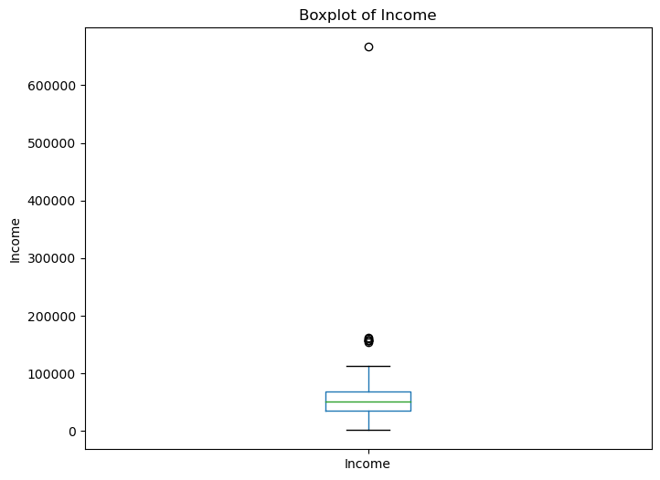

```python
plt.figure(figsize=(8, 6))
df.boxplot(column='Income')
plt.title('Boxplot of Income')
plt.ylabel('Income')
plt.grid(False)
plt.show()
```

```python
mean_income = df['Income'].mean()
std_income = df['Income'].std()
#outliers = df[(df['Income'] > (mean_income + 3 * std_income)) | (df['Income'] < (mean_income - 3 * std_income))]
#df.drop(outliers.index, inplace=True)
df.loc[(df['Income'] > (mean_income + 3 * std_income)) | (df['Income'] < (mean_income - 3 * std_income)), 'Income'] = np.nan
df.shape
```

```
(2240, 24)
```

#### we are using the standard deviation to identify outliers in the 'Income' column. By calculating the standard deviation, we can determine a threshold beyond which values are considered outliers. In this case, outliers are values that lie more than 3 standard deviations away from the mean income value. There were total 8 outliers in this income column.

### Boxplot after deleting the outliers

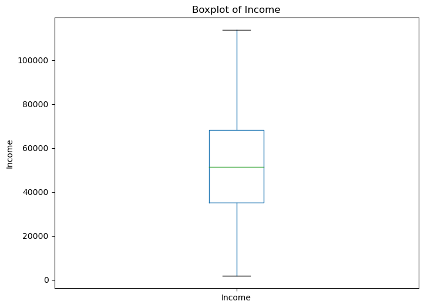

```python
plt.figure(figsize=(8, 6))
df.boxplot(column='Income')
plt.title('Boxplot of Income')
plt.ylabel('Income')
plt.grid(False)
plt.show()
```

### 20. Show quick statistics for the column Income

```python
df['Income'].describe()
```

```
count      2208.000000
mean      51633.638134
std       20713.376530
min        1730.000000
25%       35196.000000
50%       51301.000000
75%       68289.750000
max      113734.000000
Name: Income, dtype: float64
```

### 21. Show the number of missing values for each column

```python
df.isnull().sum()
```

```
ID                    0
Year_Birth            0
Education             0
Marital_Status        0
Income               32
Kidhome               0
Teenhome              0
Dt_Customer           0
Recency               0
Wines                 0
Fruits                0
Meat                  0
Fish                  0
Sweet                 0
Gold                  0
NumDealsPurchases     0
Web                   0
Catalog               0
Store                 0
Complain              0
Z_CostContact         0
Z_Revenue             0
Age                   0
Spending              0
dtype: int64
```

### 22. Fill the missing values with the average.

```python
mean_income = df['Income'].mean()
df['Income'].fillna(mean_income, inplace=True)
df
```

|  | ID | Year_Birth | Education | Marital_Status | Income | Kidhome | Teenhome | Dt_Customer | Recency | Wines | ... | Gold | NumDealsPurchases | Web | Catalog | Store | Complain | Z_CostContact | Z_Revenue | Age | Spending |
| --- | --- | --- | --- | --- | --- | --- | --- | --- | --- | --- | --- | --- | --- | --- | --- | --- | --- | --- | --- | --- | --- |
| 0 | 5524 | 1957 | Postgraduate | Alone | 58138.0 | 0 | 0 | 2012-09-04 | 58 | 635 | ... | 88 | 3 | 8 | 10 | 4 | 0 | 3 | 11 | 67 | 1617 |
| 1 | 2174 | 1954 | Postgraduate | Alone | 46344.0 | 1 | 1 | 2014-03-08 | 38 | 11 | ... | 6 | 2 | 1 | 1 | 2 | 0 | 3 | 11 | 70 | 27 |
| 2 | 4141 | 1965 | Postgraduate | Not Alone | 71613.0 | 0 | 0 | 2013-08-21 | 26 | 426 | ... | 42 | 1 | 8 | 2 | 10 | 0 | 3 | 11 | 59 | 776 |
| 3 | 6182 | 1984 | Postgraduate | Not Alone | 26646.0 | 1 | 0 | 2014-02-10 | 26 | 11 | ... | 5 | 2 | 2 | 0 | 4 | 0 | 3 | 11 | 40 | 53 |
| 4 | 5324 | 1981 | Postgraduate | Not Alone | 58293.0 | 1 | 0 | 2014-01-19 | 94 | 173 | ... | 15 | 5 | 5 | 3 | 6 | 0 | 3 | 11 | 43 | 422 |
| ... | ... | ... | ... | ... | ... | ... | ... | ... | ... | ... | ... | ... | ... | ... | ... | ... | ... | ... | ... | ... | ... |
| 2235 | 10870 | 1967 | Postgraduate | Not Alone | 61223.0 | 0 | 1 | 2013-06-13 | 46 | 709 | ... | 247 | 2 | 9 | 3 | 4 | 0 | 3 | 11 | 57 | 1341 |
| 2236 | 4001 | 1946 | Postgraduate | Not Alone | 64014.0 | 2 | 1 | 2014-06-10 | 56 | 406 | ... | 8 | 7 | 8 | 2 | 5 | 0 | 3 | 11 | 78 | 444 |
| 2237 | 7270 | 1981 | Postgraduate | Alone | 56981.0 | 0 | 0 | 2014-01-25 | 91 | 908 | ... | 24 | 1 | 2 | 3 | 13 | 0 | 3 | 11 | 43 | 1241 |
| 2238 | 8235 | 1956 | Postgraduate | Not Alone | 69245.0 | 0 | 1 | 2014-01-24 | 8 | 428 | ... | 61 | 2 | 6 | 5 | 10 | 0 | 3 | 11 | 68 | 843 |
| 2239 | 9405 | 1954 | Postgraduate | Not Alone | 52869.0 | 1 | 1 | 2012-10-15 | 40 | 84 | ... | 21 | 3 | 3 | 1 | 4 | 0 | 3 | 11 | 70 | 172 |

2240 rows × 24 columns

```python
df.isnull().sum()
```

```
ID                   0
Year_Birth           0
Education            0
Marital_Status       0
Income               0
Kidhome              0
Teenhome             0
Dt_Customer          0
Recency              0
Wines                0
Fruits               0
Meat                 0
Fish                 0
Sweet                0
Gold                 0
NumDealsPurchases    0
Web                  0
Catalog              0
Store                0
Complain             0
Z_CostContact        0
Z_Revenue            0
Age                  0
Spending             0
dtype: int64
```

### 23. Create a new column named Children to hold the total number of children for every customer.

```python
df['Children'] = df['Kidhome'] + df['Teenhome']
df
```

|  | ID | Year_Birth | Education | Marital_Status | Income | Kidhome | Teenhome | Dt_Customer | Recency | Wines | ... | NumDealsPurchases | Web | Catalog | Store | Complain | Z_CostContact | Z_Revenue | Age | Spending | Children |
| --- | --- | --- | --- | --- | --- | --- | --- | --- | --- | --- | --- | --- | --- | --- | --- | --- | --- | --- | --- | --- | --- |
| 0 | 5524 | 1957 | Postgraduate | Alone | 58138.0 | 0 | 0 | 2012-09-04 | 58 | 635 | ... | 3 | 8 | 10 | 4 | 0 | 3 | 11 | 67 | 1617 | 0 |
| 1 | 2174 | 1954 | Postgraduate | Alone | 46344.0 | 1 | 1 | 2014-03-08 | 38 | 11 | ... | 2 | 1 | 1 | 2 | 0 | 3 | 11 | 70 | 27 | 2 |
| 2 | 4141 | 1965 | Postgraduate | Not Alone | 71613.0 | 0 | 0 | 2013-08-21 | 26 | 426 | ... | 1 | 8 | 2 | 10 | 0 | 3 | 11 | 59 | 776 | 0 |
| 3 | 6182 | 1984 | Postgraduate | Not Alone | 26646.0 | 1 | 0 | 2014-02-10 | 26 | 11 | ... | 2 | 2 | 0 | 4 | 0 | 3 | 11 | 40 | 53 | 1 |
| 4 | 5324 | 1981 | Postgraduate | Not Alone | 58293.0 | 1 | 0 | 2014-01-19 | 94 | 173 | ... | 5 | 5 | 3 | 6 | 0 | 3 | 11 | 43 | 422 | 1 |
| ... | ... | ... | ... | ... | ... | ... | ... | ... | ... | ... | ... | ... | ... | ... | ... | ... | ... | ... | ... | ... | ... |
| 2235 | 10870 | 1967 | Postgraduate | Not Alone | 61223.0 | 0 | 1 | 2013-06-13 | 46 | 709 | ... | 2 | 9 | 3 | 4 | 0 | 3 | 11 | 57 | 1341 | 1 |
| 2236 | 4001 | 1946 | Postgraduate | Not Alone | 64014.0 | 2 | 1 | 2014-06-10 | 56 | 406 | ... | 7 | 8 | 2 | 5 | 0 | 3 | 11 | 78 | 444 | 3 |
| 2237 | 7270 | 1981 | Postgraduate | Alone | 56981.0 | 0 | 0 | 2014-01-25 | 91 | 908 | ... | 1 | 2 | 3 | 13 | 0 | 3 | 11 | 43 | 1241 | 0 |
| 2238 | 8235 | 1956 | Postgraduate | Not Alone | 69245.0 | 0 | 1 | 2014-01-24 | 8 | 428 | ... | 2 | 6 | 5 | 10 | 0 | 3 | 11 | 68 | 843 | 1 |
| 2239 | 9405 | 1954 | Postgraduate | Not Alone | 52869.0 | 1 | 1 | 2012-10-15 | 40 | 84 | ... | 3 | 3 | 1 | 4 | 0 | 3 | 11 | 70 | 172 | 2 |

2240 rows × 25 columns

### 24. Create a new column Has_Complaint

```python
df['Dt_Customer'] = pd.to_datetime(df['Dt_Customer'])
two_years_ago = pd.Timestamp.now() - pd.DateOffset(years=2)

# Create 'Has_Complaint' column based on conditions
df['Has_Complaint'] = df.apply(lambda row: 'Has complaint' if row['Complain'] == 1 and row['Dt_Customer'] >= two_years_ago else 'No complaint', axis=1)
df

#df[df['Has_Complaint'] == 'No complaint']
# There are no customers who has complained in the last 2 years
```

|  | ID | Year_Birth | Education | Marital_Status | Income | Kidhome | Teenhome | Dt_Customer | Recency | Wines | ... | Web | Catalog | Store | Complain | Z_CostContact | Z_Revenue | Age | Spending | Children | Has_Complaint |
| --- | --- | --- | --- | --- | --- | --- | --- | --- | --- | --- | --- | --- | --- | --- | --- | --- | --- | --- | --- | --- | --- |
| 0 | 5524 | 1957 | Postgraduate | Alone | 58138.0 | 0 | 0 | 2012-09-04 | 58 | 635 | ... | 8 | 10 | 4 | 0 | 3 | 11 | 67 | 1617 | 0 | No complaint |
| 1 | 2174 | 1954 | Postgraduate | Alone | 46344.0 | 1 | 1 | 2014-03-08 | 38 | 11 | ... | 1 | 1 | 2 | 0 | 3 | 11 | 70 | 27 | 2 | No complaint |
| 2 | 4141 | 1965 | Postgraduate | Not Alone | 71613.0 | 0 | 0 | 2013-08-21 | 26 | 426 | ... | 8 | 2 | 10 | 0 | 3 | 11 | 59 | 776 | 0 | No complaint |
| 3 | 6182 | 1984 | Postgraduate | Not Alone | 26646.0 | 1 | 0 | 2014-02-10 | 26 | 11 | ... | 2 | 0 | 4 | 0 | 3 | 11 | 40 | 53 | 1 | No complaint |
| 4 | 5324 | 1981 | Postgraduate | Not Alone | 58293.0 | 1 | 0 | 2014-01-19 | 94 | 173 | ... | 5 | 3 | 6 | 0 | 3 | 11 | 43 | 422 | 1 | No complaint |
| ... | ... | ... | ... | ... | ... | ... | ... | ... | ... | ... | ... | ... | ... | ... | ... | ... | ... | ... | ... | ... | ... |
| 2235 | 10870 | 1967 | Postgraduate | Not Alone | 61223.0 | 0 | 1 | 2013-06-13 | 46 | 709 | ... | 9 | 3 | 4 | 0 | 3 | 11 | 57 | 1341 | 1 | No complaint |
| 2236 | 4001 | 1946 | Postgraduate | Not Alone | 64014.0 | 2 | 1 | 2014-06-10 | 56 | 406 | ... | 8 | 2 | 5 | 0 | 3 | 11 | 78 | 444 | 3 | No complaint |
| 2237 | 7270 | 1981 | Postgraduate | Alone | 56981.0 | 0 | 0 | 2014-01-25 | 91 | 908 | ... | 2 | 3 | 13 | 0 | 3 | 11 | 43 | 1241 | 0 | No complaint |
| 2238 | 8235 | 1956 | Postgraduate | Not Alone | 69245.0 | 0 | 1 | 2014-01-24 | 8 | 428 | ... | 6 | 5 | 10 | 0 | 3 | 11 | 68 | 843 | 1 | No complaint |
| 2239 | 9405 | 1954 | Postgraduate | Not Alone | 52869.0 | 1 | 1 | 2012-10-15 | 40 | 84 | ... | 3 | 1 | 4 | 0 | 3 | 11 | 70 | 172 | 2 | No complaint |

2240 rows × 26 columns

### 25. Show the first 5 rows of customers with ‘No complaint’

```python
customers_with_no_complaint = df[df['Has_Complaint'] == 'No complaint']
customers_with_no_complaint.head(5)
```

|  | ID | Year_Birth | Education | Marital_Status | Income | Kidhome | Teenhome | Dt_Customer | Recency | Wines | ... | Web | Catalog | Store | Complain | Z_CostContact | Z_Revenue | Age | Spending | Children | Has_Complaint |
| --- | --- | --- | --- | --- | --- | --- | --- | --- | --- | --- | --- | --- | --- | --- | --- | --- | --- | --- | --- | --- | --- |
| 0 | 5524 | 1957 | Postgraduate | Alone | 58138.0 | 0 | 0 | 2012-09-04 | 58 | 635 | ... | 8 | 10 | 4 | 0 | 3 | 11 | 67 | 1617 | 0 | No complaint |
| 1 | 2174 | 1954 | Postgraduate | Alone | 46344.0 | 1 | 1 | 2014-03-08 | 38 | 11 | ... | 1 | 1 | 2 | 0 | 3 | 11 | 70 | 27 | 2 | No complaint |
| 2 | 4141 | 1965 | Postgraduate | Not Alone | 71613.0 | 0 | 0 | 2013-08-21 | 26 | 426 | ... | 8 | 2 | 10 | 0 | 3 | 11 | 59 | 776 | 0 | No complaint |
| 3 | 6182 | 1984 | Postgraduate | Not Alone | 26646.0 | 1 | 0 | 2014-02-10 | 26 | 11 | ... | 2 | 0 | 4 | 0 | 3 | 11 | 40 | 53 | 1 | No complaint |
| 4 | 5324 | 1981 | Postgraduate | Not Alone | 58293.0 | 1 | 0 | 2014-01-19 | 94 | 173 | ... | 5 | 3 | 6 | 0 | 3 | 11 | 43 | 422 | 1 | No complaint |

5 rows × 26 columns

# Part III: Data Visualization & Analytics

### 26. New dataframe with the columns: Age, Spending, Marital_Status, Education, Income, Children, Dt_Customer and Has_Complaint

```python
customer_profile_columns = ['Age', 'Spending', 'Marital_Status', 'Education', 'Income', 'Children', 'Dt_Customer', 'Has_Complaint']
customer_profile = df[customer_profile_columns]
customer_profile
```

|  | Age | Spending | Marital_Status | Education | Income | Children | Dt_Customer | Has_Complaint |
| --- | --- | --- | --- | --- | --- | --- | --- | --- |
| 0 | 67 | 1617 | Alone | Postgraduate | 58138.0 | 0 | 2012-09-04 | No complaint |
| 1 | 70 | 27 | Alone | Postgraduate | 46344.0 | 2 | 2014-03-08 | No complaint |
| 2 | 59 | 776 | Not Alone | Postgraduate | 71613.0 | 0 | 2013-08-21 | No complaint |
| 3 | 40 | 53 | Not Alone | Postgraduate | 26646.0 | 1 | 2014-02-10 | No complaint |
| 4 | 43 | 422 | Not Alone | Postgraduate | 58293.0 | 1 | 2014-01-19 | No complaint |
| ... | ... | ... | ... | ... | ... | ... | ... | ... |
| 2235 | 57 | 1341 | Not Alone | Postgraduate | 61223.0 | 1 | 2013-06-13 | No complaint |
| 2236 | 78 | 444 | Not Alone | Postgraduate | 64014.0 | 3 | 2014-06-10 | No complaint |
| 2237 | 43 | 1241 | Alone | Postgraduate | 56981.0 | 0 | 2014-01-25 | No complaint |
| 2238 | 68 | 843 | Not Alone | Postgraduate | 69245.0 | 1 | 2014-01-24 | No complaint |
| 2239 | 70 | 172 | Not Alone | Postgraduate | 52869.0 | 2 | 2012-10-15 | No complaint |

2240 rows × 8 columns

### 27. Create histogram to show the number of children per customers in your data.

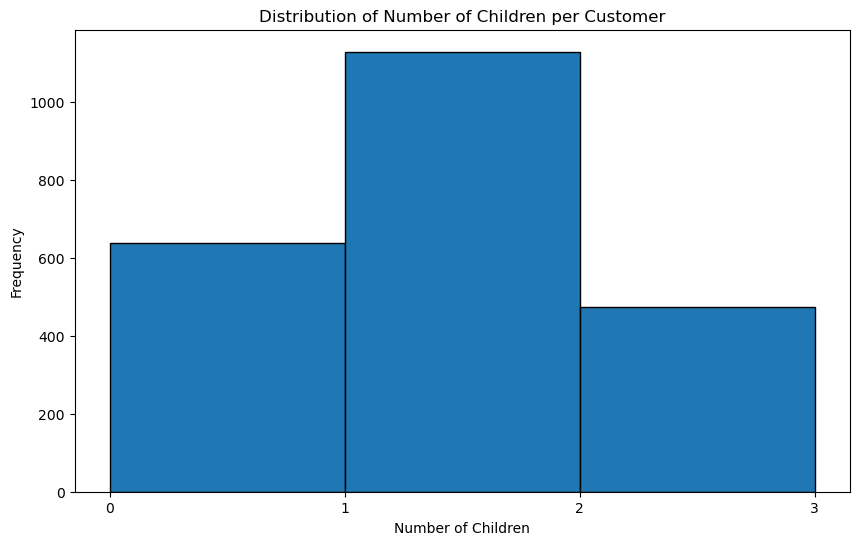

```python
plt.figure(figsize=(10, 6))
plt.hist(df['Children'], bins=range(0, max(df['Children']) + 1, 1), edgecolor='black')
plt.xlabel('Number of Children')
plt.ylabel('Frequency')
plt.xticks(np.arange(0, 4, step=1))
plt.title('Distribution of Number of Children per Customer')
plt.show()
```

### 28. Create a histogram and a Boxplot to show the Income of customers

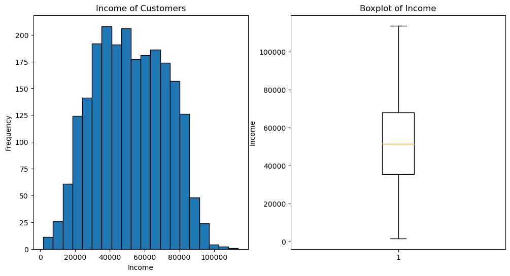

```python
plt.figure(figsize=(12, 6))
plt.subplot(1, 2, 1)
plt.hist(customer_profile['Income'], bins=20, edgecolor='black')
plt.title('Income of Customers')
plt.xlabel('Income')
plt.ylabel('Frequency')

plt.subplot(1, 2, 2)
plt.boxplot(customer_profile['Income'])
plt.title('Boxplot of Income')
plt.ylabel('Income')
plt.show()
```

### 29. Create a histogram and a Boxplot to show the Spending of customers

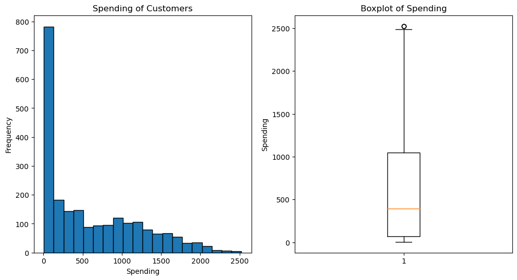

```python
plt.figure(figsize=(12, 6))
plt.subplot(1, 2, 1)
plt.hist(customer_profile['Spending'], bins=20, edgecolor='black')
plt.title('Spending of Customers')
plt.xlabel('Spending')
plt.ylabel('Frequency')

plt.subplot(1, 2, 2)
plt.boxplot(customer_profile['Spending'])
plt.title('Boxplot of Spending')
plt.ylabel('Spending')
plt.show()
```

```python
# Spending outliers
mean_spending = df['Spending'].mean()
std_spending = df['Spending'].std()
outliers = df[(df['Spending'] > (mean_spending + 3 * std_spending)) | (df['Spending'] < (mean_spending - 3 * std_spending))]
outliers['Spending']
```

```
987     2486
1052    2440
1179    2525
1492    2524
1572    2525
Name: Spending, dtype: int64
```

### Analysis:

#### - As the whiskers are not of equal lengths, it indicates that the data distribution is skewed which indicates that the majority of customers have spendings between 0 to 1000.

### 30. Create a histogram and a boxplot to analyse the customers based on their Age

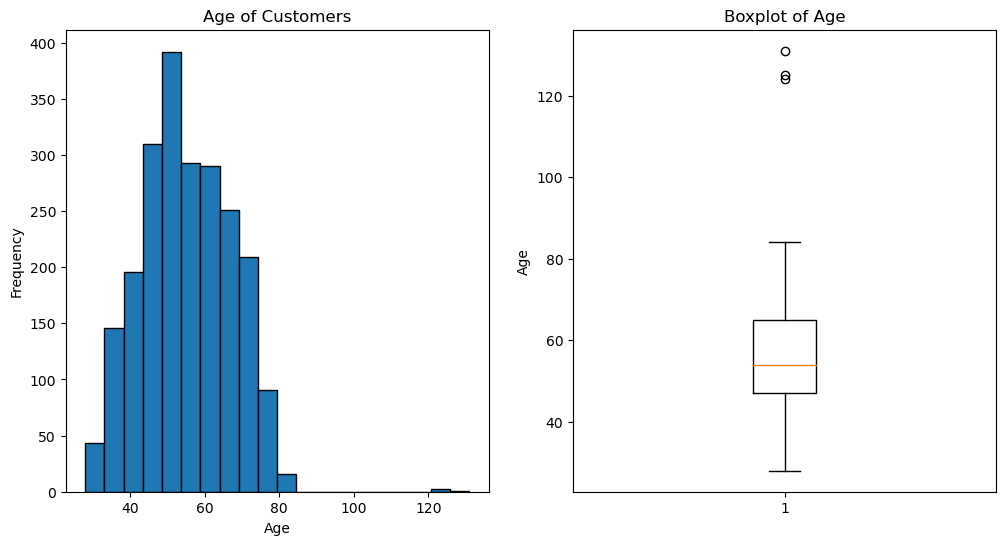

```python
plt.figure(figsize=(12, 6))
plt.subplot(1, 2, 1)
plt.hist(customer_profile['Age'], bins=20, edgecolor='black')
plt.title('Age of Customers')
plt.xlabel('Age')
plt.ylabel('Frequency')

plt.subplot(1, 2, 2)
plt.boxplot(customer_profile['Age'])
plt.title('Boxplot of Age')
plt.ylabel('Age')
plt.show()
```

```python
# Age outliers
mean_spending = df['Age'].mean()
std_spending = df['Age'].std()
outliers = df[(df['Age'] > (mean_spending + 3 * std_spending)) | (df['Age'] < (mean_spending - 3 * std_spending))]
outliers['Age']
```

```
192    124
239    131
339    125
Name: Age, dtype: int64
```

### Analysis:

#### - This case has 3 outliers, where the customers are of age more than 120 which is 124, 125 and 131.

#### - As the whiskers are of equal lengths in the boxplot, it indicates that the data distribution is not skewed.

### 31. Create a histogram to analyse the Education level of the company’s customers

```python
customer_profile[customer_profile['Education'] == 'Postgraduate'].shape
```

```
(1983, 8)
```

```python
customer_profile[customer_profile['Education'] == 'Undergraduate'].shape
```

```
(257, 8)
```

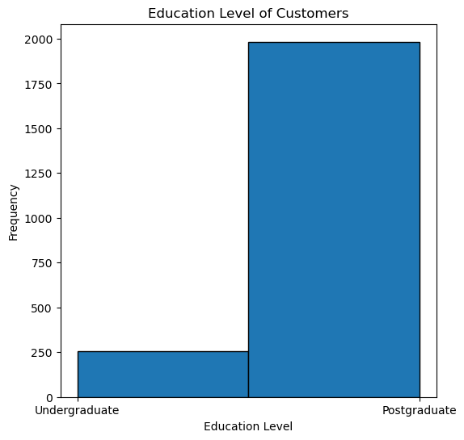

```python
customer_profile.loc[:, 'Education'] = customer_profile['Education'].replace({'Undergraduate': 0, 'Postgraduate': 1})
customer_profile.loc[:, 'Education'] = customer_profile['Education'].astype(int)

plt.figure(figsize=(6, 6))
plt.hist(customer_profile['Education'], bins=2, edgecolor='black')
plt.title('Education Level of Customers')
plt.xlabel('Education Level')
plt.ylabel('Frequency')
plt.xticks(ticks=[0, 1], labels=['Undergraduate', 'Postgraduate'])
plt.show()
```

### Analysis:

#### - From the above histogram, it is clear that most customers (about 2000) have a postgraduate education level.

#### - Nearly 250 customers have an undergraduate education level.

#### - This data indicates that the customer's literacy rate is high in this dataset.